# KB Penta+Measles

## PENTA/Measles in India

NOTE, SCHEDULE FOR PENTA is 6w, 10w, 14w, First dose of Measles is given at 9m (or is supposed to be). Looking at the age distribution for Measles dose at 9m, it seems to be given mostly between 9 and 12m. also if restrict analyses to birth cohorts born after March 2018, coverage is lower than if include earlier years as well.

Coverage of 4th dose in 12-24m olds seems to have trailed off in last few months. Is this a reporting delay or something? This problem is unique to the Measles dose (9m) and is not seen in the primary doses.

Number of kids with 1,2,3 doses Penta, or first Measles

```
##                      PENTA1
## routine.eligible.flag     0     1
##                     1   202 14224
```

```
## [1] "Number of kids with 1,2,3 doses Penta, or first Measles"
```

|  | Vaccine | N |
| --- | --- | --- |
| 1 | Penta Dose 1 | 14224 |
| 2 | Penta Dose 2 | 12635 |
| 3 | Penta Dose 3 | 11355 |
| 4 | Measles Dose 1 | 9299 |

# Uptake of 1,2,3 doses of Penta, 1 dose Measles, by birth month

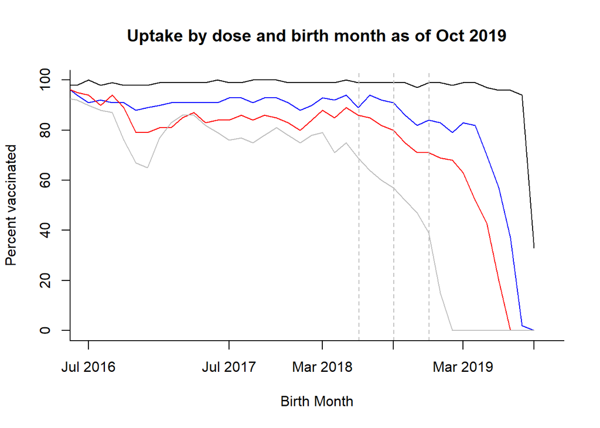

What is rate of refusal?

|  |  | Administered in other facility | Avoid wastage | Child sick | Given | Mother denies | mr me lg gya h 7/8/2019 | Multiple injections denied | Not Available | Not eligible | Out of stock |
| --- | --- | --- | --- | --- | --- | --- | --- | --- | --- | --- | --- |
| 2015 | 0 | 0 | 0 | 0 | 2 | 0 | 0 | 0 | 0 | 0 | 0 |
| 2016 | 0 | 0 | 0 | 0 | 346 | 0 | 0 | 0 | 0 | 0 | 0 |
| 2017 | 2 | 0 | 5 | 0 | 2563 | 0 | 0 | 0 | 2 | 24 | 4 |
| 2018 | 0 | 0 | 6 | 2 | 3997 | 6 | 0 | 2 | 7 | 9 | 0 |
| 2019 | 0 | 1 | 25 | 5 | 2391 | 3 | 1 | 1 | 55 | 52 | 3 |

## Look at uptake of 1,2, 3 doses by age

First look at uptake of 1,2, or booster dose by age in all kids born after March 1,2018. We restrict to this age group to match with the PCV analyses This is done as a survival model because of the structure of the data. Many kids in the database don’t become age-eligible to receive a dose, so we censor them.

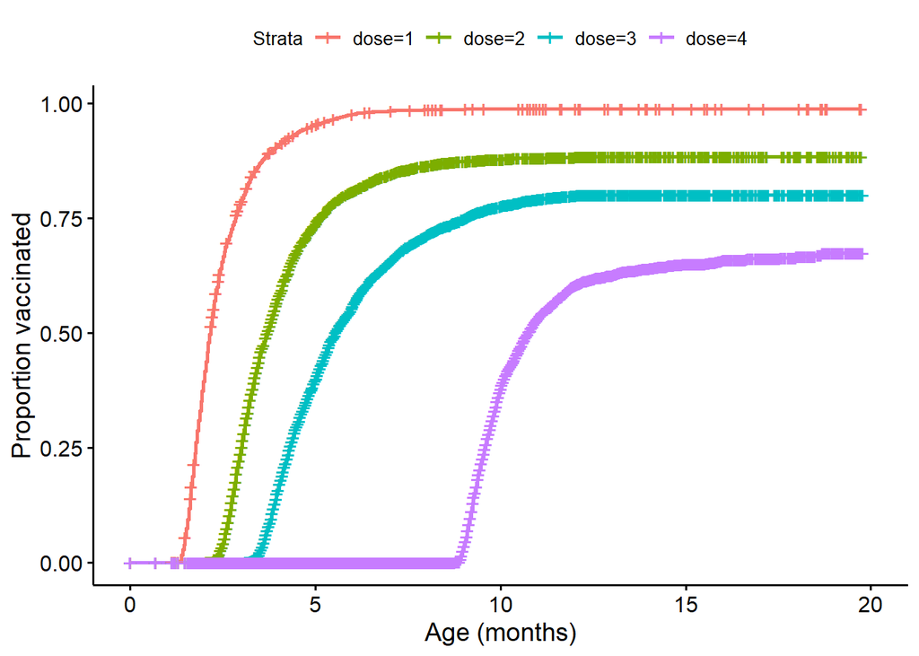

```
## [1] "Uptake"
```

```
##         1         2         3         4
## 0.9892707 0.8843155 0.8006616 0.6739711
```

## Timeliness

Define based on within 4 weeks of recomended date https://www.ncbi.nlm.nih.gov/pmc/articles/PMC5720480/ recommended is 1.5, 3.5 and 9 months

|  | doses | uptake | cov.1m | cov.2m | pct.timely1m | pct.timely2m |
| --- | --- | --- | --- | --- | --- | --- |
| 1 | 1 | 0.99 | 0.67 | 0.87 | 0.67 | 0.88 |
| 2 | 2 | 0.88 | 0.45 | 0.67 | 0.51 | 0.76 |
| 3 | 3 | 0.8 | 0.3 | 0.49 | 0.37 | 0.62 |
| 4 | 4 | 0.67 | 0.38 | 0.53 | 0.56 | 0.79 |

## Spatial variability in uptake

```
## [1] Gogunda  Jhadol   Salumbar Lasadia  Sarada
## Levels: Gogunda Jhadol Lasadia Salumbar Sarada
```

| Table 1. Number of children in the Khushi Baby database, October 2019 Admin. Region | Table 1. Number of children in the Khushi Baby database, October 2019 All Children | Table 1. Number of children in the Khushi Baby database, October 2019 Children born after Mar 2018 |
| --- | --- | --- |
| Gogunda | 3362 | 1419 |
| Jhadol | 3207 | 1483 |
| Lasadia | 900 | 484 |
| Salumbar | 3034 | 1293 |
| Sarada | 3923 | 1826 |
| Total | 14426 | 6505 |

```
##  1 Gogunda   1 Jhadol  1 Lasadia 1 Salumbar   1 Sarada  2 Gogunda
##  0.9929632  0.9847685  0.9855072  0.9989799  0.9839886  0.9198923
##   2 Jhadol  2 Lasadia 2 Salumbar   2 Sarada  3 Gogunda   3 Jhadol
##  0.8363185  0.8537587  0.9300505  0.8715528  0.8664574  0.7099585
##  3 Lasadia 3 Salumbar   3 Sarada  4 Gogunda   4 Jhadol  4 Lasadia
##  0.7906989  0.8811078  0.7683385  0.7957914  0.5403117  0.6805921
## 4 Salumbar   4 Sarada
##  0.7769845  0.6343044
```

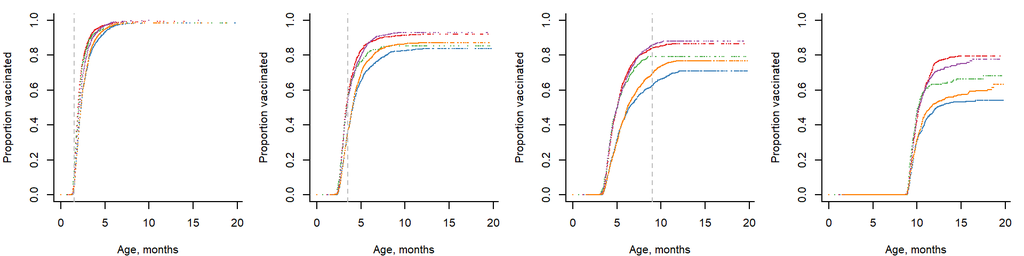

## Measles 1st dose coverage for 12-24 month old kids

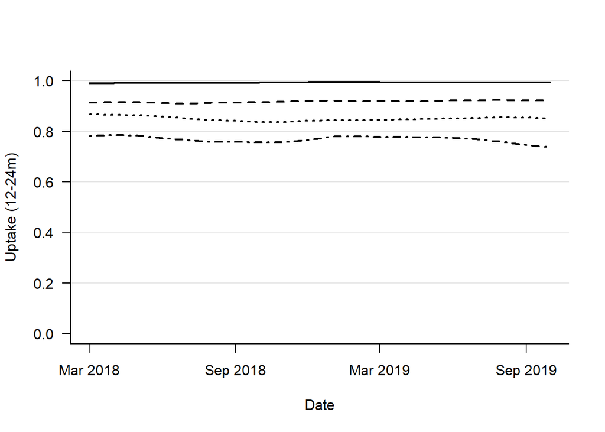

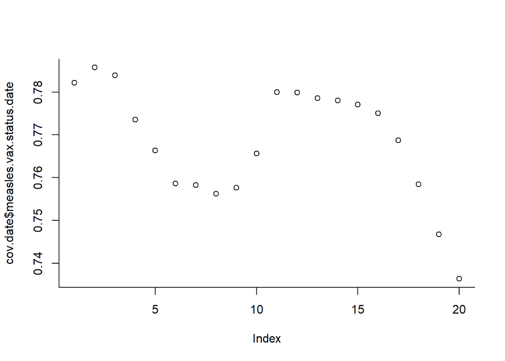

Look at 12-17m and 18-23m separately. Then recent downturn in measles 1st dose coverage is clear in the younger kids

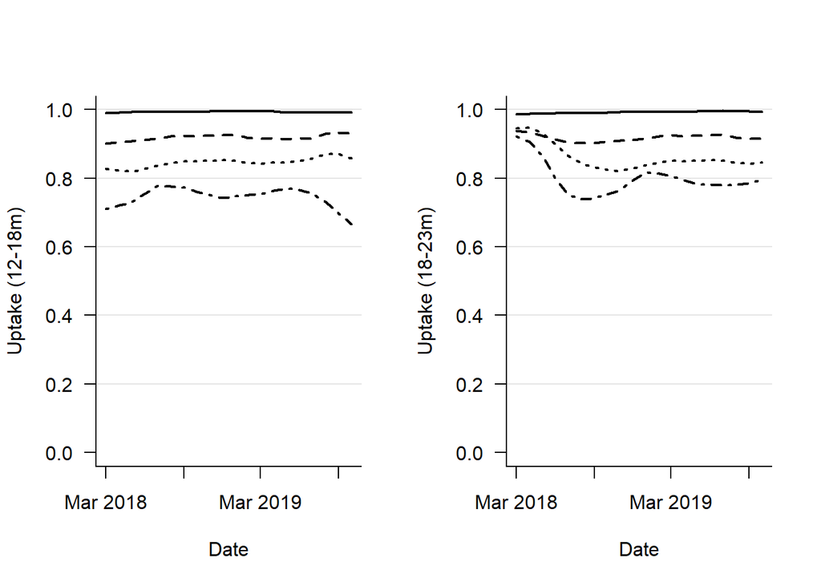

Histogram of age of kids when they are vaccinated

Timeliness for kids vaccinated in 2019

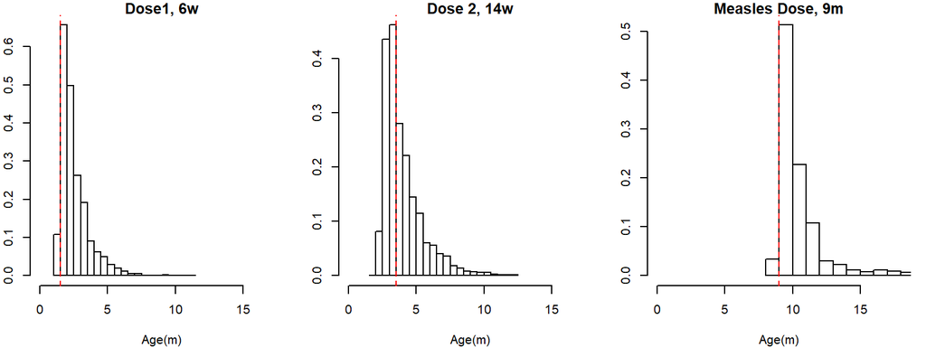